Collaboration groups are being set up in Canvas. Make sure your group starts one thread for each problem. You are required to participate in Problem 1. The goal is for the group to develop a solution after everyone has participated in Problem 1 discussion. You can start a discussion thread for Problem 2, however, do not post a complete solution. You must submit your own solutions for both problems.

# **1 - Module 10 Note this is a Collaborative Problem.**

*50 Points Total*

The RBF NN algorithm is to be used for classification of the Iris data set. In this problem the following subproblems are to be completed:

1. [10 points] Using the RBF in Section 2 of the Neural Network documentation develop in pseudocode an RBF NN (no bias) system to accomplish the following steps:
   - Develop (pseudocode) an RBF NN train/training function.
   - Develop (pseudocode) an RBF NN classification function.
2. Optional no need to discuss collaboratively - Analyze your design
   - Calculate the running time of the system above in O-notation.
   - Calculate the total running time of the above system as T(n) with each line of pseudocode or code accounted for.
   - How does the total running time T(n) compare to the running time in O-notation?
3. [40 points] Implement your developed RBF NN using Python.
   - Train three two class models using the Iris data set as input training data, the Iris data will need to be reconfigured as a one-vs-all or one-vs-one data set. For example, one vs all will have class 1 as setosa and class 2 as versicolor and virginica.
   - Process the test data set to determine which class each test observation belongs to, in this problem you will simply use all 150 observations as your test data.
   - What is the classification accuracy of your design?
   - If you had any misclassifications what was the cause of this, e.g., did the spread have an impact?

## Part 1

```
Function TrainRBFNN(training_data, num_centers, learning_rate, max_iterations)
    Initialize centers randomly selected from training_data
    Initialize weights to small random values

    Repeat until convergence or max_iterations reached:
        For each example (x, target) in training_data:
            For each center i:
                Compute distances from x to center i
                Compute RBF activation using Gaussian function:
                    activation_i = exp(-gamma * distance^2)

            Compute output by summing weighted activations:
                output = sum(weights_i * activation_i for i in centers)

            Compute error:
                error = target - output

            Update weights:
                For each weight i:
                    weights_i = weights_i + learning_rate * error * activation_i

            Optionally adjust centers and/or gamma based on error

    Return centers, weights
```

```
Function ClassifyRBFNN(input_vector, centers, weights, gamma)
    activations = []
    For each center in centers:
        Compute distance from input_vector to center
        Compute RBF activation using Gaussian function:
            activation = exp(-gamma * distance^2)
        Add activation to activations list

    Compute output by summing weighted activations:
        output = sum(weights_i * activations[i] for i in range(len(centers)))

    Return output
```

## Part 2

Certainly! Here's a condensed version of the analysis of the running time for a radial basis neural network:

### Radial Basis Neural Network Running Time Analysis

1. **Initialization**:
   - Initialize weights and biases: O(1) (constant time, done once).
2. **Forward Pass**:
   - **Input to Hidden Layer**:
     - Calculate distances between n inputs and m neurons, each of d-dimensional space: O(n \times m \times d).
     - Apply radial basis function to each distance: O(n \times m).
   - **Hidden to Output Layer**:
     - Compute output as a weighted sum of hidden outputs, with p outputs: O(n \times m \times p).

### Total Running Time T(n)

- For one input: O(m \times (d + p)).
- For all inputs: O(n \times m \times (d + p)).

### Big O Notation

- Represents the upper limit as input size grows: O(n \times m \times (d + p)), focusing on the scaling with n (number of inputs).

This format outlines the running time calculation in a streamlined way, ideal for quick reference or presentation slides.

## Part 3

```python
import numpy as np
import pandas as pd

class RBFNN_2:

    def __init__(self) -> None:
        self.model_error = 0
        self.w_hat = []
        self.w = []
        self.spread = 0
        self.predictions = []

    def fit(self, X, y, spread=None):
        if spread is None:
            spread = 0.5

        n, d = X.shape
        H = np.zeros((n,n))

        for j in range(0,n):
            for i in range(0,n):
                W = X[j,:]
                H[i,j] = np.exp(-(np.linalg.norm(X[i,:]-W))**2 / (2*spread**2))
        W_hat = np.dot(np.dot(np.linalg.pinv(np.dot(H.conj().T, H)),H.conj().T),y)
        # W_hat = np.linalg.pinv(H) * y
        yt = np.dot(H, W_hat)
        y_pred = np.ones((y.shape[0],1))
        y_pred[yt < 0] = -1
        pred_error = 1 - np.sum(y == y_pred)/y.shape[0]

        self.w_hat = W_hat
        self.w = X
        self.spread = spread
        self.model_error = pred_error

    def classify(self, X):

        n1, d1 = X.shape
        n2, d2 = self.w.shape

        H = np.zeros((n1,n2))
        for j in range(0,n2):
            for i in range(0,n1):
                W = self.w[j,:]
                H[i,j] = np.exp(-(np.linalg.norm(X[i,:]-W))**2 / (2*self.spread**2))

        y = np.dot(H, self.w_hat)
        y_hat = np.zeros((n1,1))
        for i in range(0,n1):
            for j in range(0,n2):
                W = self.w[j,:]
                W_hat = self.w_hat[j]
                y_hat[i] = y_hat[i] + W_hat*np.exp(-(np.linalg.norm(X[i,:]-W))**2 / (2*self.spread**2))
        y_pred = np.ones(y.shape)
        y_pred[y < 0] = -1
        self.predictions = y_pred
        return y_pred

    def accuracy_score(self, X, y):
        return (1 - np.sqrt(np.sum((self.predictions - y)**2))/y.shape[0])*100
```

```python
# iris = pd.read_csv("/Users/zachhatzenbeller/Documents/GitHub/Data-Science-Masters/Algorithms for Data Science/HW4/iris.csv")
iris = pd.read_csv(r"C:\Users\zhatz\Documents\GitHub\Data-Science-Masters\Algorithms for Data Science\HW4\iris.csv")

X = iris.iloc[:,:4].values
y = iris.iloc[:,4].values
y1 = y.copy()
y2 = y.copy()
y3 = y.copy()

y1[(y1 == "versicolor") | (y1 == "virginica")] = -1
y1[y1 == "setosa"] = 1

y2[(y2 == "setosa") | (y2 == "virginica")] = -1
y2[y2 == "versicolor"] = 1

y3[(y3 == "versicolor") | (y3 == "setosa")] = -1
y3[y3 == "virginica"] = 1

y1 = y1.reshape(-1,1)
y2 = y2.reshape(-1,1)
y3 = y3.reshape(-1,1)

y_list = [y1, y2, y3]

for i in y_list:
    neural_network = RBFNN_2()
    neural_network.fit(X[25:75],i[25:75])
    array = neural_network.classify(X)
    accuracy = neural_network.accuracy_score(X, i)
    print(f"Model Training Error: {neural_network.model_error}")
    print(f"Testing Set Accuracy: {accuracy}")
    print("")
```

```
Model Training Error: 0.0
Testing Set Accuracy: 100.0

Model Training Error: 0.0
Testing Set Accuracy: 90.57190958417937

Model Training Error: 0.0
Testing Set Accuracy: 90.57190958417937
```

# **2 - Module 5 and 8 Note this is not a Collaborative Problem.**

*50 Points Total*

[25 points each] Using both algorithm (minimax and alpha beta) from Figures 2 and 3, manually show the subtree with player X taking the next move at position 5 (the bottom row middle column) shown in Figure 1.

- Build the remainder of the tree and label each state with its corresponding values of each variable in the algorithm, e.g., state, player, v, move, and game.Actions(). Refer to slide 43 of the "Introduction to Adversarial Search and Game Play.pdf". Continue until you reach all leaf nodes indicating the end of the game (win, draw, loss).
- The goal is to show visually how the algorithm is exploring the node in level 0 and exploring in a downward manner reaching the leaf nodes. In the HW 4 Module, please reference the Introduction to Adversarial Search and Game Play.pdf.
- Create your solution in a separate excel spreadsheet or powerpoint slide deck. You will submit this file separately through canvas.

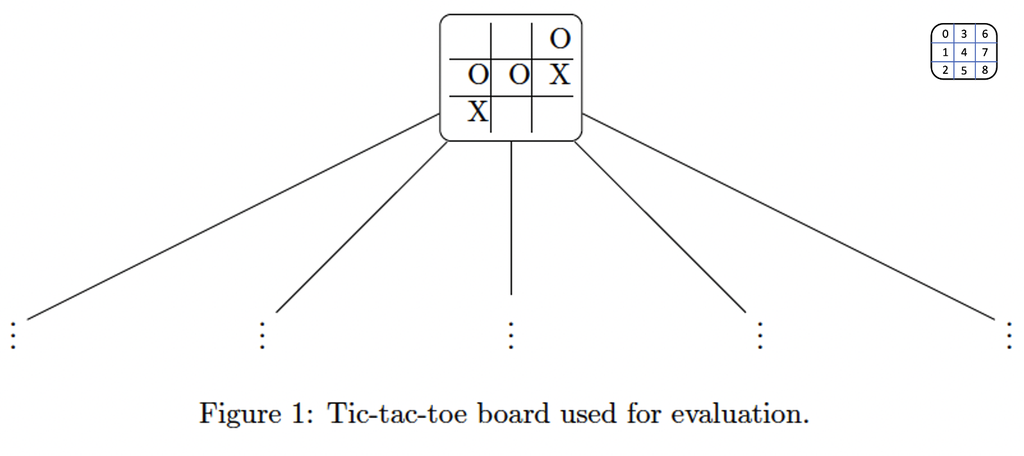

```python
%matplotlib inline
from IPython.display import Image
Image('HW4fig1_1.png')
```

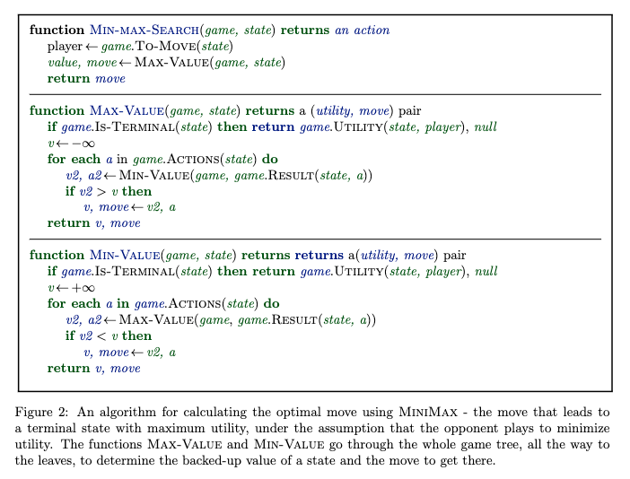

```python
Image('HW4fig2.png')
```

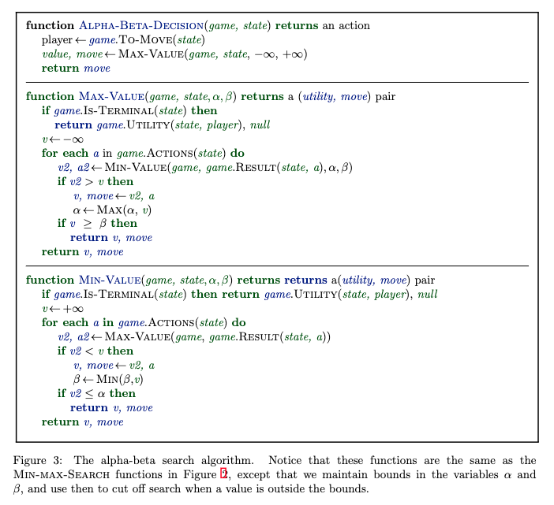

```python
Image('HW4fig3.png')
```